# Understanding Contextualized Mobility Patterns from Location-based Social Networks

Ming Li

Wednesday, September 10, 2014

before trying infering mobility patterns from the dataset, the question must be answered:

to what extend can mobility patterns be revealed from the dataset? is it predictable? how predictable is it?

[output not shown]

#### 1. some statistical results of the dataset

##### 1.1 Trajectory

[output not shown]

[output not shown]

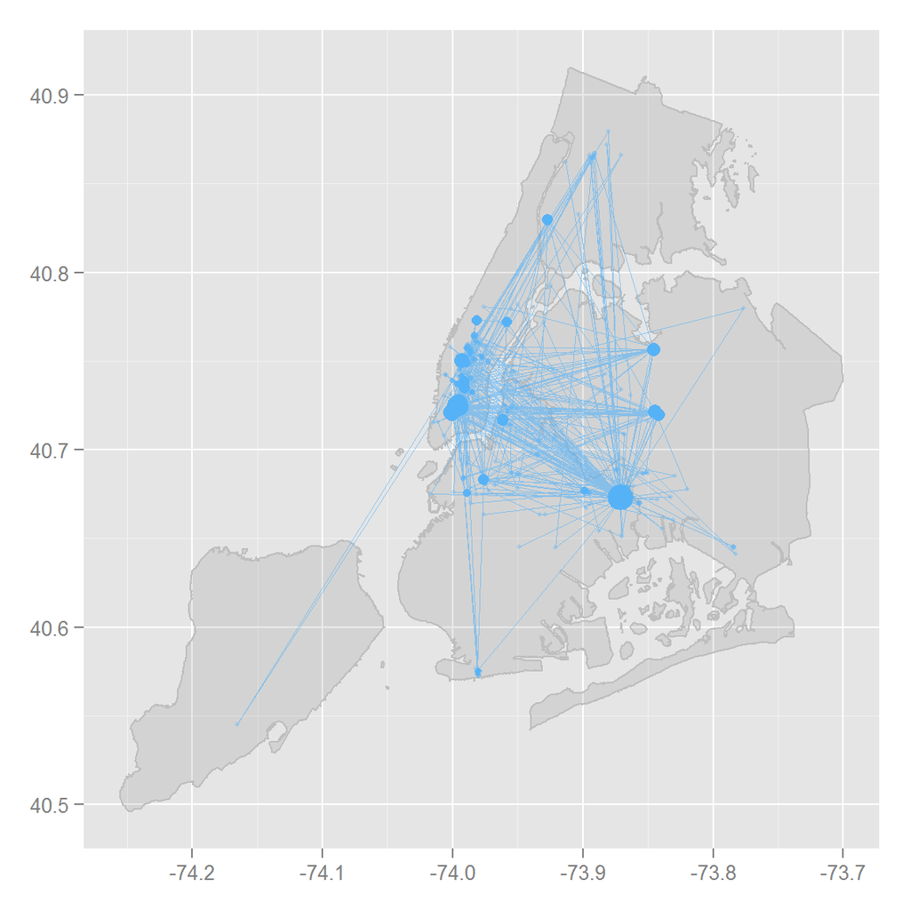

##### 1.2 CCDF and CDF

the following codes split the data by user, and get some basic statistics (e.g. checkin days, checkin per day, total checkin, etc.) into the variable *usersets.stats*

```r
# preparations
# seperate the users
days = length(unique(checkin.global$yearday))
usersets = split(checkin.global, checkin.global$user_id)

# users statistics
usersets.cnt = sapply(usersets,function(i){nrow(i)})
usersets.cates = sapply(usersets,function(i){ length(unique(i$cate_l2)) })
usersets.days = sapply(usersets,function(i){ length(unique(i$yearday)) })
usersets.cnt.perday = usersets.cnt / usersets.days
# usersets.hours = sapply(usersets,function(i){ceiling(length(unique(as.numeric(i$hour)))/3)/8})
usersets.hours = sapply(usersets,function(i){length(unique(as.numeric(i$hour)))/24})

usersets.stats = data.frame("perday"=usersets.cnt.perday,
                         "days"=usersets.days,
                         "hourcomp"=usersets.hours,
                         "totalcnt"=usersets.cnt,
                         "cates"=usersets.cates)
rm(usersets.cnt,usersets.days,usersets.cnt.perday,usersets.hours,usersets.cates)
```

Based on the basic statistics, we can answer 2 questions:

- how many percentages of users have more than X personal checkin counts ?
- how many percentages of checkins are created by X% users?

The questions are answered by the following code and figure:

```r
# 1. ccdf of personal checkin counts
# i.e.: how many percentages of users have more than X personal checkin counts ?
cnt.personal.ccdf = transform(as.data.frame(table(usersets.stats$totalcnt)),
                 ccdf=ave(Freq, FUN=function(x) 1-cumsum(x) / sum(x)))
# 2. cdf of total checkin counts
# i.e.: how many percentages of checkins are created by X% users?
cnt.total.cdf = transform(data.frame("counts"=sort(usersets.stats$totalcnt,decreasing=TRUE)),
                          user.pct = ave(1:length(counts), FUN=function(x) x/length(counts)),
                          cdf=ave(counts, FUN=function(x) cumsum(x) / sum(x)))
```

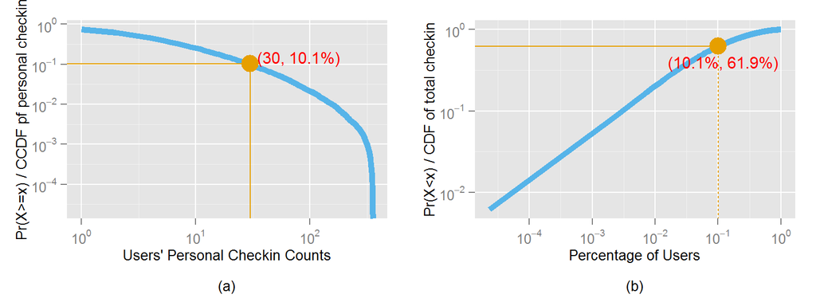

##### 1.3 Independence on data size / “active user”

We also get the subset of the first month for comparison. The statistics is done in a similar way into the variable *temp.usersets.stats*

The following figure describes the number of checkins per checkin day and the number of checkin days of all users within a period of 150 days (5 months, a) and 28 days (1 month, b). The hour completeness of each user is also expressed in (a) and (b) by colour.

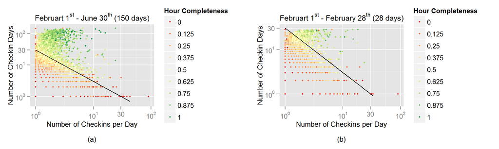

And the following figure describes the linear relations between hour completeness and users total checkin counts.

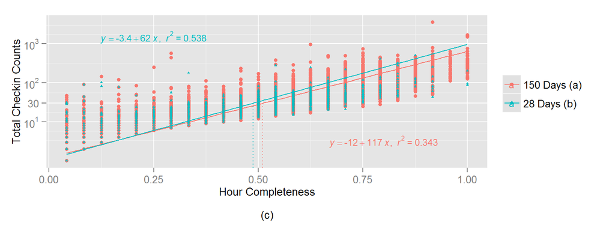

The above figures suggested that “hour completenss” can be a good criterion to define “active users”, and a reasonable threshold can be 0.5

```r
# decide "active" user sets
usersets.active.idx = which(usersets.stats$hourcomp > 0.5)
usersets.inactive.idx = which(usersets.stats$hourcomp <= 0.5)
# usersets.active.idx = which(usersets.cnt >= 30)
# usersets.inactive.idx = which(usersets.cnt < 30)
```

#### 2. some more statistics & comparisons between the two groups

##### 2.1 checkin intervals (both temporal and spatial)

```r
####################################
# basic calculation

# temporal
ave.interval.t = sapply(usersets,function(user){
    leng = nrow(user)
    t = user[order(user$timestamps.x),"timestamps.x"]
    t1 = t[1:(leng-1)]
    t2 = t[2:leng]
    delta = t2-t1
    mean(delta/3600)
})

# spatial
ave.interval.s = sapply(usersets,function(user){
    leng = nrow(user)
    s = user[order(user$timestamps.x),c("lat.x","lon.x")]
    s1 = user[1:(leng-1),]
    s2 = user[2:leng,]
    mean(sqrt(((s2$lat.x-s1$lat.x)*111319.49)^2 +
                 ((s2$lon.x-s1$lon.x)*84379.035)^2 ) /1000)
})
```

```r
####################################
# grouping

# inactive users
ave.interval.t1 = ave.interval.t[usersets.inactive.idx]
ave.interval.s1 = ave.interval.s[usersets.inactive.idx]
# active users
ave.interval.t2 = ave.interval.t[usersets.active.idx]
ave.interval.s2 = ave.interval.s[usersets.active.idx]
```

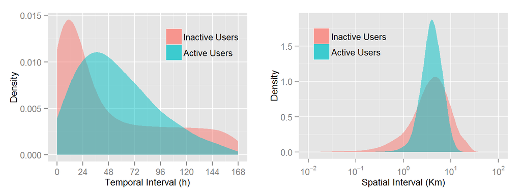

##### 2.2 daily covered distance (gyration)

```r
gyration = sapply(usersets,function(i){
    usersets.daily = split(i,i$yearday)
    sapply(usersets.daily,function(j){
        center.lat = mean(j$lat.x)
        center.lon = mean(j$lon.x)

        leng = nrow(j)
        dist.squared = ((j$"lat.x"-center.lat)*111319.49)^2 +
                       ((j$"lon.x"-center.lon)*84379.035)^2

        sqrt(mean(dist.squared)) / 1000
    })
})
```

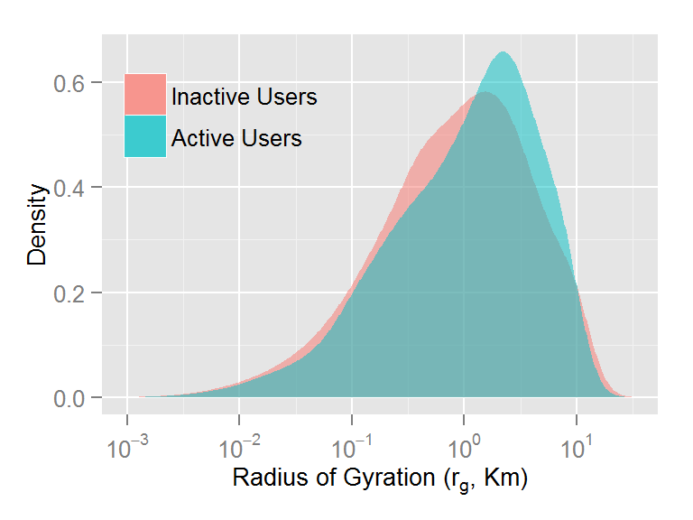

#### 3. Entropy

##### 3.1 calculation of entropy

- s-t clustering functions

```r
spatial.clustering = function(data){
    # get coordinates
    coords = data[,c("lon.x","lat.x")]
    # determine number of clusters
    ntotal = nrow(unique(coords))
    if(ntotal > 2){
        wss <- (ntotal-1) * sum(apply(coords,2,var))
        for (i in 2:(ntotal-1))
            wss[i] <- sum(kmeans(coords,centers=i)$withinss)

        ncls = length(wss[wss>0.05*wss[1]])+1
        if(ncls > (ntotal-1)) ncls = ntotal-1

        # K-Means Cluster Analysis
        clusters <- kmeans(coords,ncls)
        # get cluster means
        aggregate(coords,by=list(clusters$cluster),FUN=mean)
        # append cluster assignment
        coords <- data.frame(data$gid,data$cate_l2, coords, as.factor(clusters$cluster))
    }
    else{
        coords <- data.frame(data$gid,data$cate_l2, coords, as.factor(c(1)))
    }
    colnames(coords) = c("id","cate_l2","lon","lat","sp.cls")
    coords
}

temporal.clustering = function(data,interval=2){
    data.frame("id"=data$gid,  "cate_l2"=data$cate_l2,
               "hour.cls"=as.factor(floor(as.numeric(as.character(data$hour))/interval)))
}
```

```r
##########################
# computing
# random entropy
entropy.rand = sapply(usersets, function(i){
    N = length(unique(i$cate_l2))
    log2(N)
})

# uncorrelated entropy (heterogeneity pattern)
entropy.unc = sapply(usersets, function(i){
    cate.freq = as.data.frame(table(i$cate_l2))
    p = cate.freq$Freq / sum(cate.freq$Freq)
    p = p[p>0]
    -1 * sum(p * log2(p))
})
```

```r
# real entropy (spatiotemporal pattern)
entropy.real = sapply(usersets,function(user){

    cls.s = spatial.clustering(user)
    cls.t = temporal.clustering(user)
    cls = merge(x=cls.s, y=cls.t[c("id","hour.cls")], by.x="id", by.y="id", all.X=TRUE)

    cls$cate_l2=factor(cls$cate_l2)
    cls$st = as.factor(paste(cls$hour,cls$sp))


    freq = as.data.frame(xtabs(data=cls,~st+cate_l2))
    freq.marg = sapply(split(freq,freq$st),function(j){
        sum(j$Freq)
    })
    freq$marg = rep(freq.marg,length(unique(freq$cate_l2)))

    freq$p.joint = freq$Freq / sum(freq$Freq)
    freq$p.marg = freq$marg / sum(freq.marg)
    p = freq[freq$Freq>0,c("p.joint","p.marg")]
    entropy = sum(p$p.joint * log2(p$p.marg / p$p.joint))

    entropy
})
```

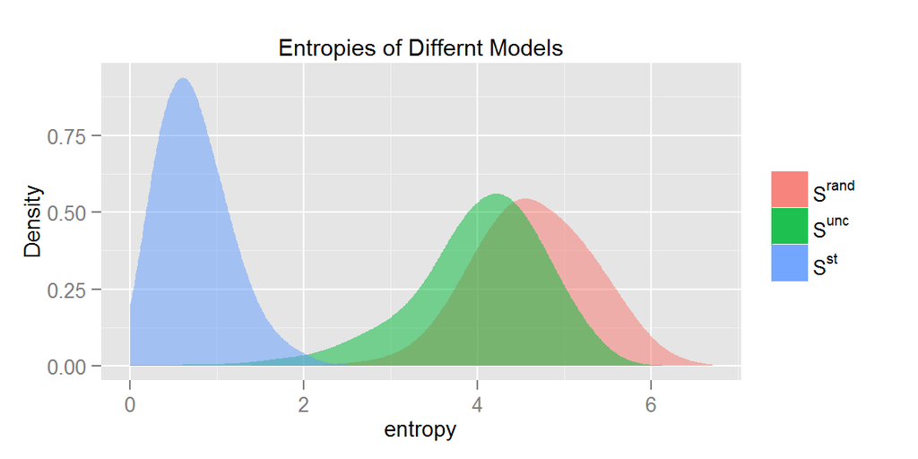

##### 3.2 entropy’s relation with a series of factors

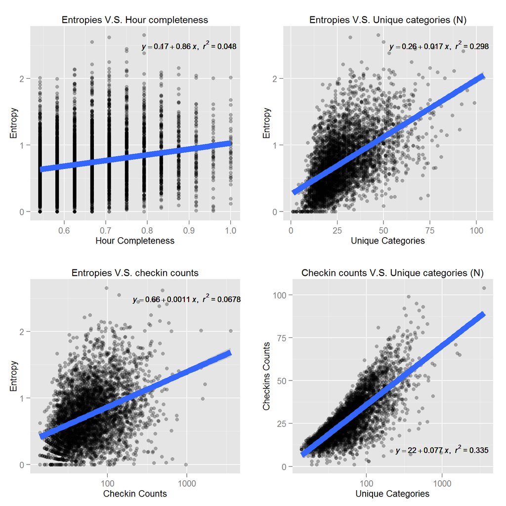

#### 4. Regularity as lower bounds

##### 4.1 calculation of regularity

```r
usersets.active = usersets[usersets.active.idx]

# reg.s.t = lapply(usersets.active, function(user){
#
#     cls.s = spatial.clustering(user)
#     cls.t = temporal.clustering(user)
#     cls = merge(x=cls.s, y=cls.t[c("id","hour.cls")], by.x="id", by.y="id", all.X=TRUE)
#     cls = merge(x=cls, y = user[c("gid","yearday")], by.x="id", by.y="gid", all.X=TRUE)
#
#     cls$cate_l2=factor(cls$cate_l2)
#     cls$st = as.factor(paste(cls$hour,cls$sp))
#
#
# #     the most probable category for this user considering both spatial and temporal
#     pi.st = sapply(split(cls,cls$st),function(st){
#         cate_seq = st$cate_l2
#         # the most probable category
#         cate_freq = as.data.frame(table(cate_seq))
# #         if(length(unique(st$yearday))>1)
#             ans = max(cate_freq$Freq)/sum(cate_freq$Freq)
# #         else ans = NA
#         ans
#     })
#
#
#
#     freq.st = as.data.frame(table(cls$st))
#     p.st = freq.st$Freq/sum(freq.st$Freq)
#
#     sum(p.st * pi.st,na.rm=TRUE)
#
# #     c("temp"=pi.t,"sp"=pi.s)
# })

reg.t = sapply(usersets.active, function(user){


    user$cate_l2=factor(user$cate_l2)
    user$hour = factor(user$hour)


#     the most probable category for this user in that hour
    pi.t = sapply(split(user,user$hour),function(hour){
        cate_seq = hour$cate_l2
        # the most probable category
        cate_freq = as.data.frame(table(cate_seq))
#         if(length(unique(st$yearday))>1)
            ans = max(cate_freq$Freq)/sum(cate_freq$Freq)
#         else ans = NA
        ans
    })



    freq.t = as.data.frame(table(user$hour))
    p.t = freq.t$Freq/sum(freq.t$Freq)

    sum(p.t * pi.t,na.rm=TRUE)

})
```

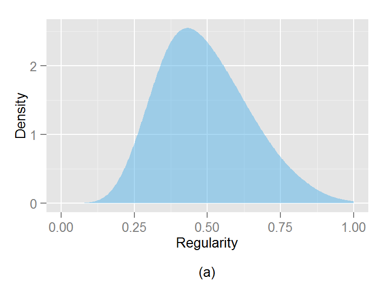

##### 4.2 relations with other factors

```r
usersets.active = usersets[usersets.active.idx]
# relation between "regularity" and "hour"
reg.t.mat = sapply(usersets.active, function(user){

    user$cate_l2=factor(user$cate_l2)

#     the most probable category for this user in that hour
    pi.t = sapply(split(user,user$hour),function(hour){
        cate_seq = hour$cate_l2
        # the most probable category
        cate_freq = as.data.frame(table(cate_seq))
#         if(length(unique(st$yearday))>1)
            ans = max(cate_freq$Freq)/sum(cate_freq$Freq)
#         else ans = NA
        ans
    })

    pi.t[is.na(pi.t)]=0

    pi.t

})
```

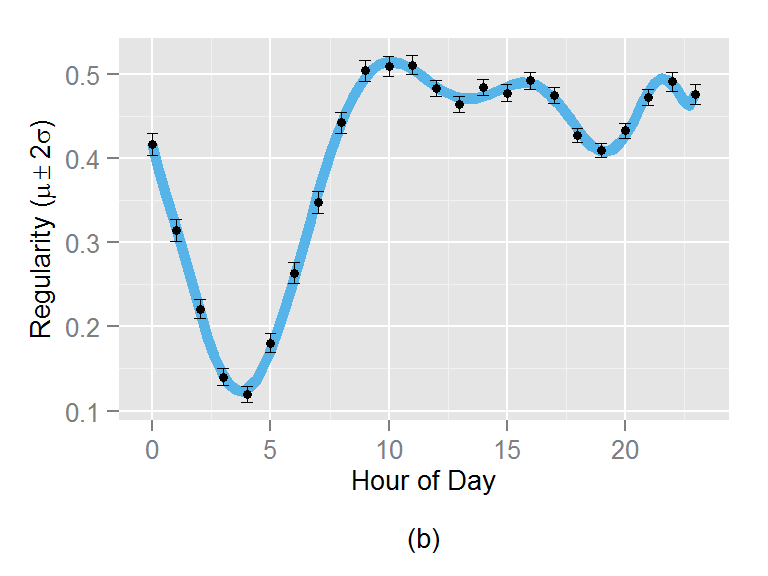

```r
# relations between hour and N
n.t.mat = sapply(usersets.active, function(user){

    user$cate_l2=factor(user$cate_l2)

#   n in each hour for this user
    n.t = sapply(split(user,user$hour),function(hour){
        length(unique(hour$cate_l2))
    })

    n.t[is.na(n.t)]=0

    n.t

})
```

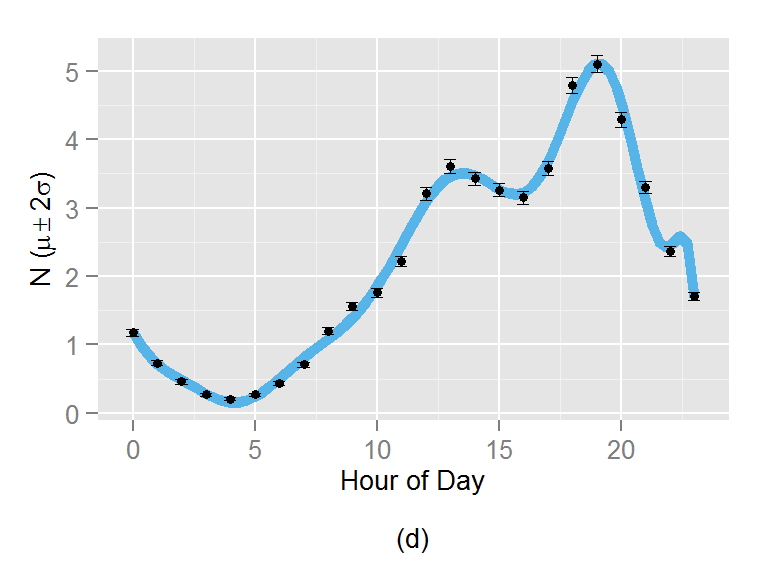

[output not shown]

[output cut: 4408 more lines]

#### 5. upper bounds based on Fano’s inequality

##### 5.1 Fano’s inequality

Fano’s inquality states:

$H(X|Y)\leq H(e)+p(e)\log(N-1)$

where

$p(e)=p(X\neq Y)=1-\Pi$

and

$H(e)=-p(e) \log p(e)-(1-p(e)) \log (1-p(e))$

It is tranlated in our case to:

$S^{real}\leq -\Pi \log \Pi - (1-\Pi)\log(1-\Pi)+(1-\Pi)\log(N-1)$

The mathmatical relations is described in the following figure:

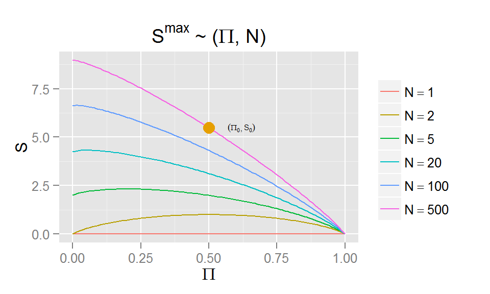